# EFFECT OF VARIABLES ON LOAN CREDIT

## by KHALIFA MUYIDEEN

## Investigation Overview

> This is a close look at how various attributes affect the amount of loan a inndividual can access and the APR of such loan. The main focus circles around the original loan amount, the prosper rating, Borrower APR and Income rate

## Dataset Overview

> The original data from prosper includes 113937 rows of data with 87 variables. Variables with less than 50% valuable data was cleared after wrangling of the data making the total data consist of 84853 rows annd 70 variables.

## Loan Original Amount Distribution

> This te the distribution of the original loan amount accessed by borrowers according to the data from prosper. More borrowers have accessed lesser value from 25k annd below.

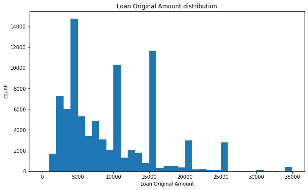

## BorrowAPR against the Loan Original Amount

> Although, the APR has a broad range for a lesser amount of loan. The amount of interest decreases with increase in loan amount.

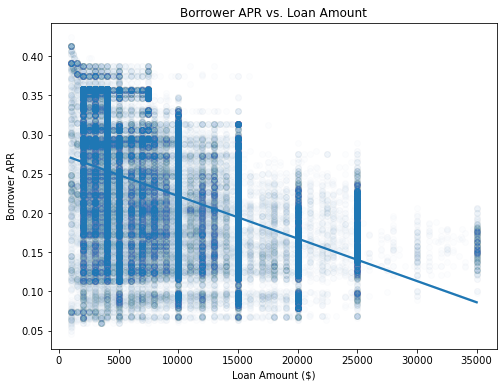

## Relationship between BorrowerAPR, LoanOriginalAmout annd ProsperRating

> This shows a clearer relationship between how Loan amount is affected by the prosper rating. It also shows how the loan amount affects the interest rate of the borrower.

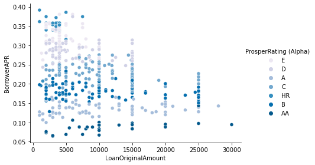